# Statystyczna analiza danych

2022-12-01

**CEL PRACY**

Zawartość tej pracy skupia się głównie na zastosowaniu metod Maching Learningu, które zostaną wykorzystane do prognozowania, czy dany pacjent ma chorobę serca. Wykonano i opisano zachowanie się danych stosując następujące metody: **metodę KNN**, **klasyfikator naiwny Bayesa** oraz **regresję logistyczną**. Zastosowanie tych metod zostało poprzedzone wykonaniem wstępnej analizy danych, zbadaniem wpływu zmiennych objaśniających na zmienną objaśnianą i odpowiednim przygotowaniem danych.

**OPIS DANYCH**

- **Wiek**: wiek pacjenta [lata]
- **Płeć**: płeć pacjenta [M: mężczyzna, F: kobieta]
- **RestingBP**: ciśnienie spoczynkowe [mm Hg]
- **Cholesterol**: cholesterol w surowicy [mm/dl]
- **FastingBS**: poziom cukru we krwi na czczo [1: jeśli FastingBS > 120 mg / dl, 0: w przeciwnym razie]
- **MaxHR**: maksymalne osiągnięte tętno [wartość liczbowa między 60 a 202]
- **Oldpeak**: oldpeak = ST [Wartość liczbowa mierzona w depresji]
- **ExerciseAngina**: dławica piersiowa wywołana wysiłkiem [Y: Tak, N: Nie]
- **HeartDisease**: klasa wyjściowa [1: choroba serca, 0: normalna (brak)]

**WPROWADZENIE**

Po wczytaniu danych sprawdzono jakiego typu są dane w celu wstępnego rozpoznania. Funkcja **str()** pokazuje jakie kolumny są w zestawie danych i jakiego typu są to wartości.

```r
#wczytanie danych
dane <- read_csv("heart.csv")
structure <- str(dane)
```

```r
show <- head(dane)
kbl(show) %>%
  kable_classic(bootstrap_options = "striped", full_width = F)
```

| Age | Sex | ChestPainType | RestingBP | Cholesterol | FastingBS | RestingECG | MaxHR | ExerciseAngina | Oldpeak | ST_Slope | HeartDisease |
| --- | --- | --- | --- | --- | --- | --- | --- | --- | --- | --- | --- |
| 40 | M | ATA | 140 | 289 | 0 | Normal | 172 | N | 0.0 | Up | 0 |
| 49 | F | NAP | 160 | 180 | 0 | Normal | 156 | N | 1.0 | Flat | 1 |
| 37 | M | ATA | 130 | 283 | 0 | ST | 98 | N | 0.0 | Up | 0 |
| 48 | F | ASY | 138 | 214 | 0 | Normal | 108 | Y | 1.5 | Flat | 1 |
| 54 | M | NAP | 150 | 195 | 0 | Normal | 122 | N | 0.0 | Up | 0 |
| 39 | M | NAP | 120 | 339 | 0 | Normal | 170 | N | 0.0 | Up | 0 |

Następnie usunięto dane tekstowe i dokonano zamiany wybranych zmiennych kategorycznych na zmienne zero-jedynkowe, aby zapobieć utracie kluczowych zmiennych.

```r
dane <- dane[,-c(3,7,11)]
dane$Sex <- ifelse(dane$Sex== 'M', 1, 0)
dane$ExerciseAngina <- ifelse(dane$ExerciseAngina== 'Y', 1, 0) #Y-1=posiadanie dławicy wysiłkowej
# zamiana kolejnośći kolumn w celu przejrzystości
dane <- dane[, c(1, 3, 4, 6, 8,2,5,7,9)]
```

Poniższa tabela zawiera statystyki dotyczące badanego zestawu danych.

```r
statystyki <- summary(dane)
kbl(statystyki) %>%
  kable_classic(bootstrap_options = "striped", full_width = F)
```

|  | Age | RestingBP | Cholesterol | MaxHR | Oldpeak | Sex | FastingBS | ExerciseAngina | HeartDisease |
| --- | --- | --- | --- | --- | --- | --- | --- | --- | --- |
|  | Min. :28.00 | Min. : 80.0 | Min. : 85.0 | Min. : 60.0 | Min. :-2.6000 | Min. :0.0000 | Min. :0.0000 | Min. :0.0000 | Min. :0.0000 |
|  | 1st Qu.:47.00 | 1st Qu.:120.0 | 1st Qu.:173.2 | 1st Qu.:120.0 | 1st Qu.: 0.0000 | 1st Qu.:1.0000 | 1st Qu.:0.0000 | 1st Qu.:0.0000 | 1st Qu.:0.0000 |
|  | Median :54.00 | Median :130.0 | Median :223.0 | Median :138.0 | Median : 0.6000 | Median :1.0000 | Median :0.0000 | Median :0.0000 | Median :1.0000 |
|  | Mean :53.51 | Mean :132.5 | Mean :230.3 | Mean :136.8 | Mean : 0.8874 | Mean :0.7898 | Mean :0.2331 | Mean :0.4041 | Mean :0.5534 |
|  | 3rd Qu.:60.00 | 3rd Qu.:140.0 | 3rd Qu.:267.0 | 3rd Qu.:156.0 | 3rd Qu.: 1.5000 | 3rd Qu.:1.0000 | 3rd Qu.:0.0000 | 3rd Qu.:1.0000 | 3rd Qu.:1.0000 |
|  | Max. :77.00 | Max. :200.0 | Max. :603.0 | Max. :202.0 | Max. : 6.2000 | Max. :1.0000 | Max. :1.0000 | Max. :1.0000 | Max. :1.0000 |

Jak można zauważyć, dane są bardzo różnorodne. Minimalny wiek badanych to 28 lat, a maksymalny to 77. Średnio każdy badany pacjent ma 53 lata, z tego wynika, że najwięcej osób w tym wieku podejrzewa się o chorobę serca. Informacje w tej tabeli niewiele mówią nam na temat płci, ponieważ są to zmienne zero-jedynkowe, jednak można zauważyć, że skoro średnia to 0,7898, a 1 - reprezentuje płeć męską, to w naszych danych przeważają mężczyźni. RestingBP (ciśnienie spoczynkowe) jest w przedziale od 80 mmHg do 200. Średnio ciśnienie wynosi 132,5 - czyli delikatnie powyżej normy. Cholesterol mieści się w zakresie 85 mg/dl aż do 603 mg/dl. Tak duża wartość może wynikać z indywidualnego przypadku zdrowotnego. Średnia Fasting BP, czyli poziom cukru wynosi 0,2331, a z uwagi na to, że to zmienna zero-jedynkowa i wartości 0 oznaczają poziom cukru mniejszy od 120 mg / dl, a norma to 80–140 mg/dl, można uznać, że większość badanych ma prawidłowy poziom cukru. MaxHR zawiera się w przedziale od 60 do 202. Średnio badani mają tętno na poziomie 136,8. ExerciseAngina, czyli dławica piersiowa wywołana wysiłkiem przyjmuje się średnią 0,4 - czyli około 40% z 918 badanych jej doświadczyło. Wartości Oldpeak (Wartość liczbowa mierzona w depresji) wahają się w od -2,6 do 6,2. Średnia HeartDisease wynosi 0,5534 - można stwierdzić, że rozkład pacjentów z chorobą serca i bez choroby serca jest prawie równomierny, lecz to pacjentów z chorobą serca jest więcej. Z tabeli wynika także, że nie ma brakujących danych.

**MACIERZ KORELACJI**

Aby lepiej zapoznać się z danymi, wykonano macierz korelacji pomiędzy zmiennymi wykorzystując korelację rang Kendalla.

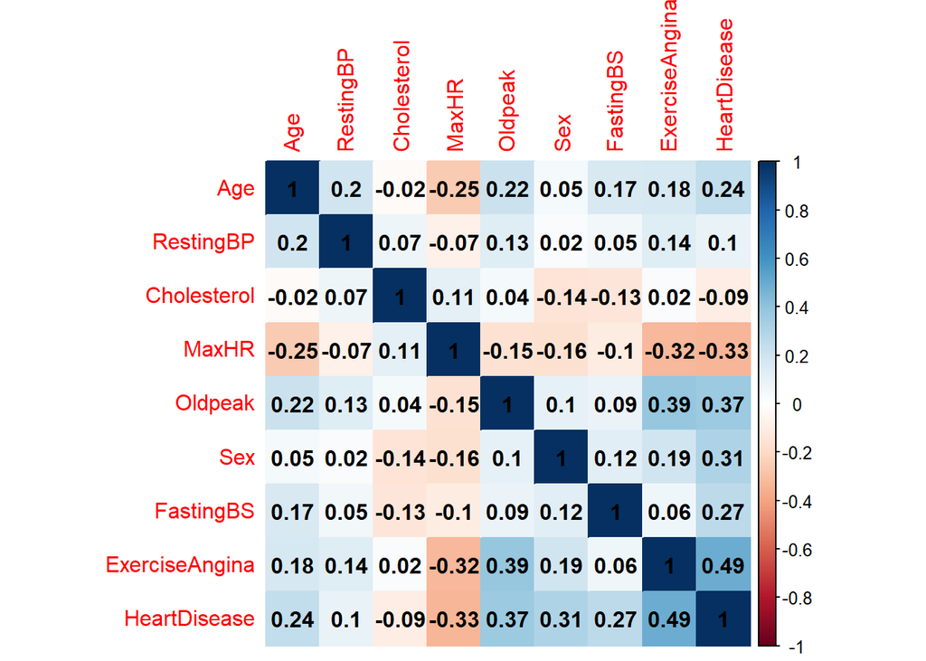

```r
corr = cor(dane,method="kendall") #zmiana na kendalla
corrplot(corr, method="color", addCoef.col = "black")
```

### **ANALIZA WPŁYWU ZMIENNYCH NA ZMIENNĄ PROGNOZOWANĄ Y**

Wykonanie wykresów badających wpływ zmiennych na zmienna prognozowaną Y.[^3]

[figure not shown]

```r
wykresy <- par( mfrow= c(1,2))
par(mar=c(5, 4, 2,6)+ 0.1, xpd=TRUE)
boxplot(RestingBP~HeartDisease,data=dane, col=(c("gold","darkgreen")))
legend("topright", inset=c(-0.8, 0), legend=c("0 - Chory","1 - Zdrowy"), title="Legend")
par(mar=c(5, 4, 2, 6) + 0.1, xpd=TRUE)
boxplot(Cholesterol~HeartDisease,data=dane, col=(c("gold","darkgreen")))
legend("topright", inset=c(-0.8, 0), legend=c("0 - Chory","1 - Zdrowy"), title="Legend")
```

[figure not shown]

```r
wykresy <- par( mfrow= c(1,2))
par(mar=c(5, 4, 2,6)+ 0.1, xpd=TRUE)
boxplot(Age~HeartDisease,data=dane, col=(c("gold","darkgreen")))
legend("topright", inset=c(-0.8, 0), legend=c("0 - Chory","1 - Zdrowy"), title="Legend")
par(mar=c(5, 4, 2, 6) + 0.1, xpd=TRUE)
boxplot(MaxHR~HeartDisease,data=dane, col=(c("gold","darkgreen")))
legend("topright", inset=c(-0.8, 0), legend=c("0 - Chory","1 - Zdrowy"), title="Legend")
```

[figure not shown]

```r
#wykresy <- par( mfrow= c(1,2))
par(mar=c(5, 4, 2,6)+ 0.1, xpd=TRUE)
boxplot(Oldpeak~HeartDisease,data=dane, col=(c("gold","darkgreen")))
legend("topright", inset=c(-0.235, 0), legend=c("0 - Chory","1 - Zdrowy"), title="Legend")
```

Z powyższych wykresów możemy wywnioskować, że wybrane zmienne (RestingBP, MaxHR, Age, Oldpeak) mają wpływ na zmienną objaśnianą - nie znajdują się na tym samym poziomie. Jedynie na wykresie Cholesterol i HeartDiesease wykresy są na tym samym poziome - co może niekorzystnie wpłynąć na predykcję. Jednak cholesterol jest kluczowym parametrem przy chorobach serca - zdecydowano się zostawić tę zmienną.

#### **ROZKŁADY ZMIENNYCH PRZEDSTAWIONE NA HISTOGRAMACH I ZA POMOCĄ KRZYWEJ GĘSTOŚCI**

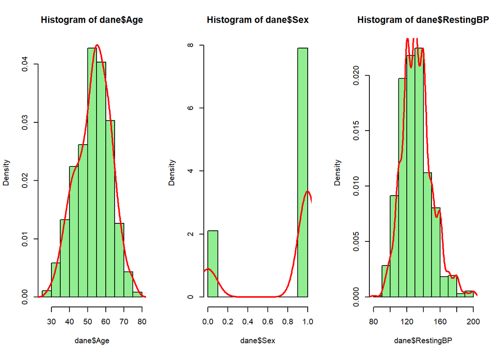

```r
wykresy <- par( mfrow= c(1,3) )
hist(dane$Age, col="lightgreen", border="black",
     prob = TRUE)
lines(density(dane$Age),
      lwd = 2,
      col = "red")

hist(dane$Sex, col="lightgreen", border="black",
     prob = TRUE)
lines(density(dane$Sex),
      lwd = 2,
      col = "red")

hist(dane$RestingBP, col="lightgreen", border="black",
     prob = TRUE)
lines(density(dane$RestingBP),
      lwd = 2,
      col = "red")
```

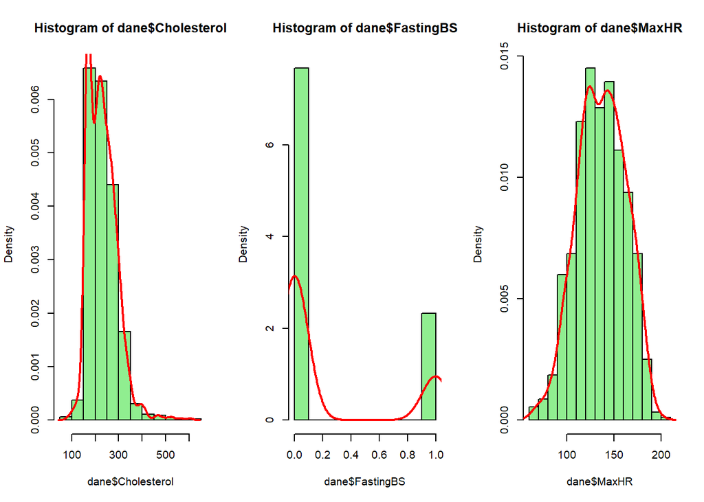

```r
hist(dane$Cholesterol, col="lightgreen", border="black",
     prob = TRUE)
lines(density(dane$Cholesterol),
      lwd = 2,
      col = "red")

hist(dane$FastingBS, col="lightgreen", border="black",
     prob = TRUE)
lines(density(dane$FastingBS),
      lwd = 2,
      col = "red")

hist(dane$MaxHR, col="lightgreen", border="black",
     prob = TRUE)
lines(density(dane$MaxHR),
      lwd = 2,
      col = "red")
```

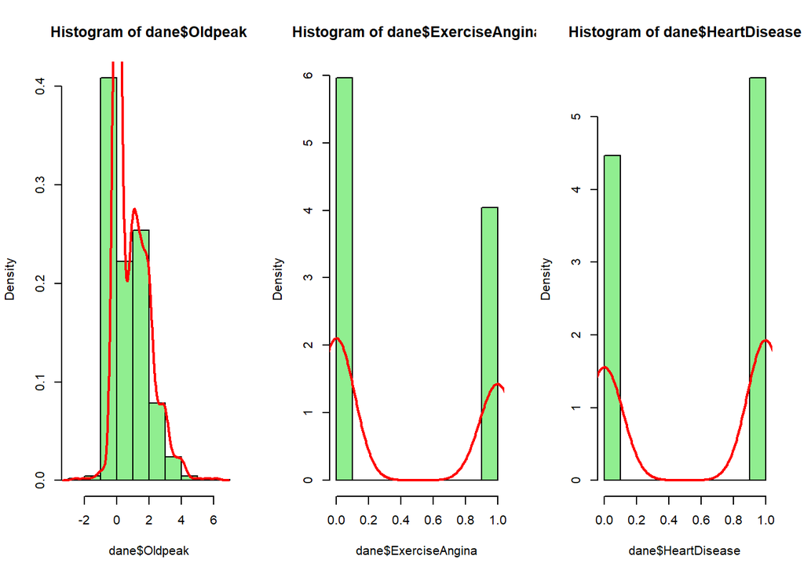

```r
hist(dane$Oldpeak, col="lightgreen", border="black",
     prob = TRUE)
lines(density(dane$Oldpeak),
      lwd = 2,
      col = "red")

hist(dane$ExerciseAngina, col="lightgreen", border="black",
     prob = TRUE)
lines(density(dane$ExerciseAngina),
      lwd = 2,
      col = "red")

hist(dane$HeartDisease, col="lightgreen", border="black",
     prob = TRUE)
lines(density(dane$HeartDisease),
      lwd = 2,
      col = "red")
```

Patrząc na wykresy można stwierdzić, że rozkład zmiennych (za wyjątkiem zmiennych zero-jedynkowych) przypominają rozkład normalny. Ze względu na dużą liczbę obserwacji, trudno jest otrzymać rozkład normalny.

**PODZIAŁ DANYCH** [^4]

Zbiór danych został podzielony na zbiór uczący i zbiór testowy, przyjęto, że 75% danych to zbiór uczący, natomiast pozostałe 25% to zbiór testowy.

```r
set.seed(1)
podzial <- sample(c(TRUE, FALSE), nrow(dane), replace=TRUE, prob=c(0.75,0.25))
uczacy  <- dane[podzial, ]
testowy   <- dane[!podzial, ]
a <- dim(uczacy)
b <- dim(testowy)
cbind(uczacy=a, testowy=b)
```

```
##      uczacy testowy
## [1,]    693     225
## [2,]      9       9
```

**STANDARYZACJA DANYCH**

```r
daneb <- dane
dane = as.data.frame(dane)

for(i in 1:5){
  dane[,i] = (dane[,i] - mean(dane[,i])) / sd(dane[,i])
  i=i+1
}
```

Dane po zestandaryzowaniu wyglądają następująco:

```r
display <- head(dane)
kbl(display) %>%
  kable_classic(bootstrap_options = "striped", full_width = F)
```

| Age | RestingBP | Cholesterol | MaxHR | Oldpeak | Sex | FastingBS | ExerciseAngina | HeartDisease |
| --- | --- | --- | --- | --- | --- | --- | --- | --- |
| -1.4323590 | 0.4145987 | 0.9604857 | 1.3821748 | -0.8319789 | 1 | 0 | 0 | 0 |
| -0.4782229 | 1.5263313 | -0.8223317 | 0.7537463 | 0.1056060 | 0 | 0 | 0 | 1 |
| -1.7504044 | -0.1412675 | 0.8623490 | -1.5243071 | -0.8319789 | 1 | 0 | 0 | 0 |
| -0.5842380 | 0.3034255 | -0.2662235 | -1.1315393 | 0.5743984 | 0 | 0 | 1 | 1 |
| 0.0518527 | 0.9704650 | -0.5769899 | -0.5816643 | -0.8319789 | 1 | 0 | 0 | 0 |
| -1.5383741 | -0.6971338 | 1.7782919 | 1.3036212 | -0.8319789 | 1 | 0 | 0 | 0 |

**METODA KNN**

K-najbliższych sąsiadów (KNN) to rodzaj nadzorowanego algorytmu uczenia używanego zarówno do regresji, jak i klasyfikacji. KNN próbuje przewidzieć prawidłową klasę danych testowych, obliczając odległość między danymi testowymi a wszystkimi punktami treningowymi. Następnie wybierz liczbę punktów K, która jest bliska danym testowym. Algorytm KNN oblicza prawdopodobieństwo wyboru danych testowych należących do klas “K” i klasy o najwyższym prawdopodobieństwie. W przypadku regresji wartością jest średnia z wybranych punktów treningowych “K”. [^5]

```r
library(class)
```

Pierwszym krokiem jest znalezienie optymalnej wartości “k”. W tym celu obliczymy pierwiastek kwadratowy z całkowitej liczby obserwacji w zbiorze danych treningowych.

```r
sqrt(NROW(uczacy$HeartDisease))
```

```
## [1] 26.32489
```

Pierwiastek kwadratowy z 693 wynosi około 26.32. W celu wybrania najlepszego k wykonano metodę ‘łokcia’ i wykres maksymalnej dokładności.[^6]

```r
i=1
k_optm=1
set.seed(12)
for (i in 1:28){
knn_mod <- knn(train=uczacy, test=testowy, cl=uczacy$HeartDisease, k=i)
k_optm[i] <- 100 * sum(testowy$HeartDisease == knn_mod)/NROW(testowy$HeartDisease)
k=i
cat(k,'=',k_optm[i],'')
}
```

[output not shown]

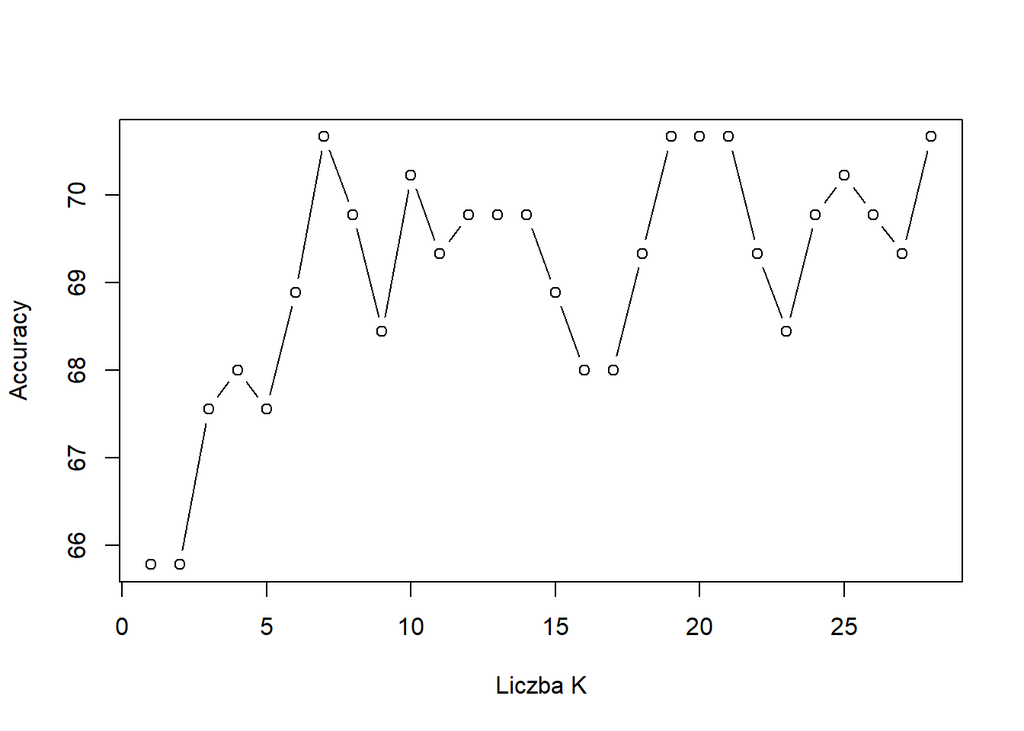

```r
plot(k_optm, type="b", xlab="Liczba K",ylab="Accuracy")
```

Z wykresu maksymalnej dokładności jak i z otrzymanych wartości, widać, że model powinien przyjać k = 7. Źle dobrana wartość k może skutkować złe wnioski o modelu. Należy zwrócić uwagę, że niskie k może doprowadzić do zaburzenia wyników, natomiast wyższe k może sprawić, że wyniki bedą charakteryzować się dużą zmiennością.

**ZBIÓR UCZĄCY**

```r
set.seed(12)

  knn_uczacy<-knn(train = uczacy[,-9],
                       test = uczacy[,-9],
                       cl=uczacy$HeartDisease,
                       k=7)
```

Kolejnym krokiem jest analiza jakości klasyfikacji. **Macierz błędu -** służy do oceny wydajności algorytmu klasyfikacji. **TP** - prawdziwie dodatni **TN** - prawdziwie ujemny **FP** - fałszywie dodatni **FN** - fałszywie ujemny

```r
 macierz_u_knn<-table(knn_uczacy, uczacy$HeartDisease)
  macierz_u_knn
```

```
##
## knn_uczacy   0   1
##          0 226  80
##          1  78 309
```

Na podstawie macierzy błędów oblicza się różne miary wydajności klasyfikacji, które są pomocne w ocenie jej poprawności. Im mniejsza będzie rozbieżność pomiędzy wartościami zbioru uczącego, a testowego tym lepiej. Jednak gdy będą znaczne różnice pomiędzy tymi dwoma zbiorami będzie to oznaczać, że model jest przecuczony.

Przystąpiono do analizy klasyfikacji dokładności.

```r
# dokładność
acc_u_knn<-((macierz_u_knn[1,1]+macierz_u_knn[2,2])/sum(macierz_u_knn))
# czułość
czul_knn_uczacy<-((macierz_u_knn[1,1])/(macierz_u_knn[1,1]+macierz_u_knn[2,1]))
# specyficzność
spec_knn_uczacy<-((macierz_u_knn[2,1])/(macierz_u_knn[1,2]+macierz_u_knn[2,2]))

cbind(Dokładnosc = acc_u_knn, Czulosc = czul_knn_uczacy, Specyficznosc=spec_knn_uczacy)
```

```
##      Dokładnosc   Czulosc Specyficznosc
## [1,]  0.7720058 0.7434211     0.2005141
```

**KRZYWA ROC**

Krzywa ROC Obrazuje ona jak duży będzie odsetek błędnych klasyfikacji pozytywnych i negatywnych dla danego punktu odcięcia, to znaczy, że prezentuje dwie wartości: y= czułość, x= specyficzność. Model jest tym lepszy im bardziej krzywa ROC unosi się nad krzywą y=x.

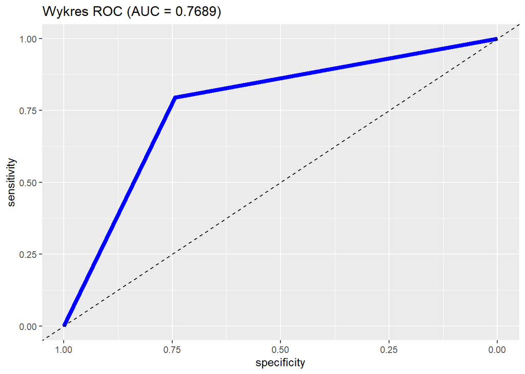

```r
krzywa_ROC_u<-roc(uczacy$HeartDisease, as.numeric(knn_uczacy))
auc <- round(auc(uczacy$HeartDisease, as.numeric(knn_uczacy)),4)
ggroc(krzywa_ROC_u, colour = 'blue', size = 2) +
ggtitle(paste0('Wykres ROC ', '(AUC = ', auc, ')'))+
geom_abline(intercept=1, linetype="dashed")
```

AUC to pole powierzchni pod krzywą ROC. Im większy wskaźnik AUC tym lepiej, w powyższym przypadku jest on równy 76,9% co oznacza, że jest to dosyć dobry model.

**ZBIÓR TESTOWY**

Model dla zbioru testowego Wykonano model również dla zbioru testowego, aby porównać otrzymane poniżej wartości z wartościami jakie otrzymano w zbiorze uczącym.

```r
set.seed(12)
knn_testowy<-knn(train = uczacy[,-9],
                test = testowy[,-9],
                cl=uczacy$HeartDisease,
                       k=7)
```

Macierz błędów

```r
 macierz_t_knn<-table(knn_testowy, testowy$HeartDisease)
  macierz_t_knn
```

```
##
## knn_testowy   0   1
##           0  59  19
##           1  47 100
```

```r
# dokładność
acc_t_knn<-((macierz_t_knn[1,1]+macierz_t_knn[2,2])/sum(macierz_t_knn))
# czułość
czul_knn_testowy<-((macierz_t_knn[1,1])/(macierz_t_knn[1,1]+macierz_t_knn[2,1]))
# specyficzność
spec_knn_testowy<-((macierz_t_knn[2,1])/(macierz_t_knn[1,2]+macierz_t_knn[2,2]))

cbind(Dokładnosc = acc_t_knn, Czulosc = czul_knn_testowy, Specyficznosc=spec_knn_testowy)
```

```
##      Dokładnosc   Czulosc Specyficznosc
## [1,]  0.7066667 0.5566038      0.394958
```

**KRZYWA ROC**

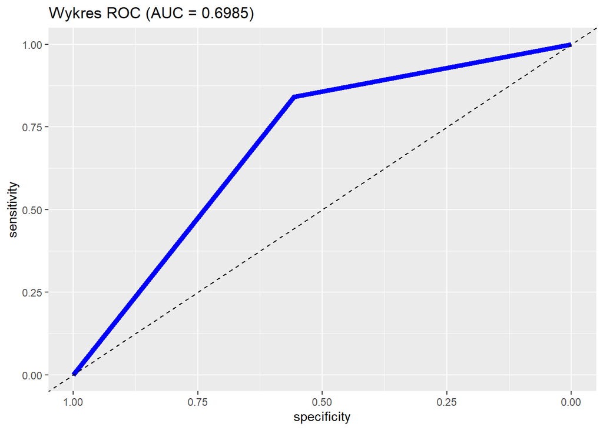

```r
krzywa_ROC_t<-roc(testowy$HeartDisease, as.numeric(knn_testowy))
auc <- round(auc(testowy$HeartDisease, as.numeric(knn_testowy)),4)
ggroc(krzywa_ROC_t, colour = 'blue', size = 2) +
ggtitle(paste0('Wykres ROC ', '(AUC = ', auc, ')'))+
geom_abline(intercept=1, linetype="dashed")
```

Pole pod krzywą ROC -AUC przyjeła gorszą wartość niż w przypadku zbioru uczącego. AUC=69,85% oznacza, że nie można tego modelu nazwać modelem teoretycznie idealnym ale nie jest to również model losowy.

Wnioski z powyższej analizy: **Model KNN** nie jest przeuczony, różnice między wartościami zbiorów nie odstają od siebie znacząco. Zaobserwowano, że model lepiej przewiduje chorobe serca dla zbioru uczącego.

#### **KLASYFIKATOR NAIWNY BAYESA**

```r
str(dane)
shapiro.test(dane$Age)
shapiro.test(dane$RestingBP)
shapiro.test(dane$Cholesterol)
shapiro.test(dane$MaxHR)
shapiro.test(dane$Oldpeak)
shapiro.test(dane$Sex)
shapiro.test(dane$FastingBS)
shapiro.test(dane$ExerciseAngina)
shapiro.test(dane$HeartDisease)
```

[output not shown]

Przekształcając dane ilościowe (dane ilościowe nie są w tej metodzie standaryzowane, ponieważ standaryzacja nie jest konieczna) na zmienne kategoryczne podzielimy je na 4 grupy wg. podziału na kwartyle. Naszym celem jest podzielić dane tak, aby każda grupa miała taką samą liczbę obserwacji, czyli po 25% z całego zbioru danych . Z racji różnorodności danych, taki podział będzie uniwersalny. [^7]

```r
library(dplyr)
grupa = 4
dane_bayes1<-daneb%>%mutate(QuantileAge = cut(daneb$Age,
        breaks = unique(quantile(daneb$Age,probs=seq.int(0,1, by=1/grupa))),
                                                 include.lowest=TRUE))
#head(dane_bayes)
dane_bayes2<-dane_bayes1%>%mutate(QuantileRestingBP = cut(daneb$RestingBP,
        breaks = unique(quantile(daneb$RestingBP,probs=seq.int(0,1, by=1/grupa))),
                                                 include.lowest=TRUE))
dane_bayes3<-dane_bayes2%>%mutate(QuantileCholesterol = cut(daneb$Cholesterol,
      breaks = unique(quantile(daneb$Cholesterol,probs=seq.int(0,1, by=1/grupa))),
                                                 include.lowest=TRUE))
dane_bayes4<-dane_bayes3%>%mutate(QuantileMaxHR = cut(daneb$MaxHR,
            breaks = unique(quantile(daneb$MaxHR,probs=seq.int(0,1, by=1/grupa))),
                                                 include.lowest=TRUE))
dane_bayes5<-dane_bayes4%>%mutate(QuantileOldpeak = cut(daneb$Oldpeak,
            breaks = unique(quantile(daneb$Oldpeak,probs=seq.int(0,1, by=1/grupa))),
                                                 include.lowest=TRUE))

dane_bayes_last <- dane_bayes5[,-c(1,2,3,4,5)]
#str(dane_bayes_last)
dane_bayes_last$Sex<-as.factor(dane_bayes_last$Sex)
dane_bayes_last$FastingBS<-as.factor(dane_bayes_last$FastingBS)
dane_bayes_last$ExerciseAngina<-as.factor(dane_bayes_last$ExerciseAngina)
dane_bayes_last$HeartDisease<-as.factor(dane_bayes_last$HeartDisease)


#str(dane_bayes_last)

dane_bayes1%>%group_by(QuantileAge)%>%count()
dane_bayes2%>%group_by(QuantileRestingBP)%>%count()
dane_bayes3%>%group_by(QuantileCholesterol)%>%count()
dane_bayes4%>%group_by(QuantileMaxHR)%>%count()
dane_bayes5%>%group_by(QuantileOldpeak)%>%count()
```

Zestaw danych po dyskretyzacji:

| Sex | FastingBS | ExerciseAngina | HeartDisease | QuantileAge | QuantileRestingBP | QuantileCholesterol | QuantileMaxHR | QuantileOldpeak |
| --- | --- | --- | --- | --- | --- | --- | --- | --- |
| 1 | 0 | 0 | 0 | [28,47] | (130,140] | (267,603] | (156,202] | [-2.6,0] |
| 0 | 0 | 0 | 1 | (47,54] | (140,200] | (173,223] | (138,156] | (0.6,1.5] |
| 1 | 0 | 0 | 0 | [28,47] | (120,130] | (267,603] | [60,120] | [-2.6,0] |
| 0 | 0 | 1 | 1 | (47,54] | (130,140] | (173,223] | [60,120] | (0.6,1.5] |
| 1 | 0 | 0 | 0 | (47,54] | (140,200] | (173,223] | (120,138] | [-2.6,0] |
| 1 | 0 | 0 | 0 | [28,47] | [80,120] | (267,603] | (156,202] | [-2.6,0] |

W następnym kroku podzielono zbiór danych na zbiór uczący i zbiór testowy.

```r
#podział danych po dyskretyzacji
set.seed(1)
podzial <- sample(c(TRUE, FALSE), nrow(dane_bayes_last), replace=TRUE, prob=c(0.75,0.25))
uczacyb <- dane_bayes_last[podzial, ]
testowyb <- dane_bayes_last[!podzial, ]
a <- dim(uczacyb)
b <- dim(testowyb)
cbind(uczacyb=a, testowyb=b)
```

Spośród 918 obserwacji dane zostały podzielone w następujący sposób: 75% danych (693 obserwacji) jako zbiór uczący i 25% danych (225 obserwacji) jako zbiór testowy.

- **ZBIÓR UCZĄCY**

Do wykonania modelu Bayesa została użyta funkcja **naiveBayes** z pakietu **e1071**. Poniżej przedstawiono tabelę, która opisuje wydajność modelu klasyfikacji na zbiorze danych uczących.

```r
###### metoda Bay"esa
#install.packages("naivebayes")
library(naivebayes)
library(e1071)
#install.packages("caret")
library(caret)
## dla zbioru uczącego
set.seed(1)
model_bayes <- naiveBayes(uczacyb$HeartDisease ~ ., data = uczacyb)
predict_bayes<- predict(model_bayes, uczacyb)
#bayes
######
#tabela_uczacy  <- table(bayes, uczacyb$HeartDisease)
#acc_uczacy <- (tabela_uczacy[1,1]+tabela_uczacy[2,2])/sum(tabela_uczacy)
#str(uczacyb$HeartDisease)
#uczacyb$HeartDisease <- as.factor(uczacyb$HeartDisease)
#str(bayes)
model_bayes_result<- confusionMatrix(predict_bayes, reference = uczacyb$HeartDisease, positive="1")
model_bayes_result
```

```
## Confusion Matrix and Statistics
##
##           Reference
## Prediction   0   1
##          0 242  73
##          1  62 316
##
##                Accuracy : 0.8052
##                  95% CI : (0.7737, 0.8341)
##     No Information Rate : 0.5613
##     P-Value [Acc > NIR] : <2e-16
##
##                   Kappa : 0.606
##
##  Mcnemar's Test P-Value : 0.3894
##
##             Sensitivity : 0.8123
##             Specificity : 0.7961
##          Pos Pred Value : 0.8360
##          Neg Pred Value : 0.7683
##              Prevalence : 0.5613
##          Detection Rate : 0.4560
##    Detection Prevalence : 0.5455
##       Balanced Accuracy : 0.8042
##
##        'Positive' Class : 1
##
```

**Dokładność** (ACC) wynosi w przybliżeniu 81% - niestety, nie jest to perfekcyjny model, lecz model na pewno można go uznać za model, który jest wystarczający, i który w 81% prawidłowo sklasyfikuje pacjenta z określonymi parametrami zdrowotnymi jako osobę z chorobą serca lub jako osobę bez choroby serca.

**Specyficzność** (TPR) wynosi około 80%, czyli wskaźnik prawdziwie negatywnych wyników. Jeżeli pacjent zostanie sklasyfikowany jako chory, to w 80% będzie naprawdę chory, a w 20% wynik diagnozy będzie fałszywie dodatni.

- **ZBIÓR TESTOWY**

```r
## dla zbioru testowego
set.seed(1)
model_bayes <- naiveBayes(testowyb$HeartDisease ~ ., data = testowyb)
predict_bayes<- predict(model_bayes, testowyb)
#bayes
######
#tabela_testowy  <- table(bayes, testowyb$HeartDisease)
#acc_testowy <- (tabela_testowy[1,1]+tabela_testowy[2,2])/sum(tabela_testowy)
#str(testowyb$HeartDisease)
#testowyb$HeartDisease <- as.factor(testowyb$HeartDisease)
#str(bayes)
model_bayes_result<- confusionMatrix(predict_bayes, reference = testowyb$HeartDisease, positive="1")
model_bayes_result
```

```
## Confusion Matrix and Statistics
##
##           Reference
## Prediction   0   1
##          0  87  16
##          1  19 103
##
##                Accuracy : 0.8444
##                  95% CI : (0.7904, 0.8892)
##     No Information Rate : 0.5289
##     P-Value [Acc > NIR] : <2e-16
##
##                   Kappa : 0.6874
##
##  Mcnemar's Test P-Value : 0.7353
##
##             Sensitivity : 0.8655
##             Specificity : 0.8208
##          Pos Pred Value : 0.8443
##          Neg Pred Value : 0.8447
##              Prevalence : 0.5289
##          Detection Rate : 0.4578
##    Detection Prevalence : 0.5422
##       Balanced Accuracy : 0.8432
##
##        'Positive' Class : 1
##
```

**Dokładność** (ACC) wynosi w przybliżeniu 84% - niestety, nie jest to perfekcyjny model, lecz model na pewno można go uznać za model, który jest wystarczający, i który w 84% prawidłowo sklasyfikuje pacjenta z określonymi parametrami zdrowotnymi jako osobę z chorobą serca lub jako osobę bez choroby serca.

**Czułość** (TPR) wynosi w zaokręgleniu 87%, czyli wskaźnik prawdziwie dodatnich wyników. Jeżeli pacjent zostanie sklasyfikowany jako zdrowy, to w 87% będzie naprawdę zdrowy, a w 13% wynik diagnozy będzie fałszywie ujemny.

**Specyficzność** (TPR) wynosi około 82%, czyli wskaźnik prawdziwie negatywnych wyników. Jeżeli pacjent zostanie sklasyfikowany jako chory, to w 82% będzie naprawdę chory, a w 18% wynik diagnozy będzie fałszywie dodatni.

#### **REGRESJA LOGISTYCZNA** [^8]

```r
#install.packages("stats")
library(stats)

model<-glm(HeartDisease~ ., family="binomial", data = uczacy)
summary(model)
```

```
##
## Call:
## glm(formula = HeartDisease ~ ., family = "binomial", data = uczacy)
##
## Coefficients:
##                  Estimate Std. Error z value Pr(>|z|)
## (Intercept)    -0.2735318  1.2735471  -0.215   0.8299
## Age             0.0283990  0.0121831   2.331   0.0198 *
## RestingBP      -0.0027201  0.0059718  -0.455   0.6488
## Cholesterol    -0.0004355  0.0018636  -0.234   0.8152
## MaxHR          -0.0201844  0.0045276  -4.458 8.27e-06 ***
## Oldpeak         0.6334658  0.1203182   5.265 1.40e-07 ***
## Sex             1.2306225  0.2617903   4.701 2.59e-06 ***
## FastingBS       1.1339140  0.2630795   4.310 1.63e-05 ***
## ExerciseAngina  1.6566911  0.2377465   6.968 3.21e-12 ***
## ---
## Signif. codes:  0 '***' 0.001 '**' 0.01 '*' 0.05 '.' 0.1 ' ' 1
##
## (Dispersion parameter for binomial family taken to be 1)
##
##     Null deviance: 950.25  on 692  degrees of freedom
## Residual deviance: 612.54  on 684  degrees of freedom
## AIC: 630.54
##
## Number of Fisher Scoring iterations: 5
```

Zmienne nieistotne to: RestingBP, Cholesterol.

Zmienne istotne:

- **Im większe MaxHR (maksymalne osiągniete tętno), tym niższe prawdopodobieństwo choroby serca.**
- **Im wyższe Oldpeak (wartość liczbowa mierzona w depresji), tym wyższe prawdopodobieństwo choroby serca.**
- **Bycie mężczyzną zwiększa prawdopodobieństwo choroby serca.**
- **Im wyższe FastingBP (poziom cukru we krwi na czczo), tym większe prawdopodobieństwo choroby serca.**
- **Posiadanie dusznicy wysiłkowej zwiększa prawdopodobieństwo zachorowania na serce.**

Oceniono jakie zmienne wpływają na zmienną objaśnianą. Poniżej zostanie przeprowadzona ocena wydajności na zbiorze testowym.

Za pomocą funkcji **predict()** obliczono prawdopodobieństwo zachorowania na serce dla każdej obserwacji w zbiorze testowym. Jako próg odcięcia przyjęto wartośc 0,5. Użycie funkcji **ifelse()** pozwala porównać czy uzyskane wcześniej prawdopodobieństwo jest większe od przyjętego progu odcięcia. Zatem jeżeli prawdopodobieństwo okaże się większe niż 0,5, należy przyjąć, że dana osoba ma chore serce.

```r
#prawdopodobientwo posiadania choroby serca dla każdej obserwacji
testowy$przewidywania = predict(model, testowy, type = "response")
#jesli prawdopodobieństwo jest większe od 0,5 to bedzie choroba serca
testowy$p = ifelse(testowy$przewidywania > 0.5, "1", "0")
testowy$p = as.factor(testowy$p)
#macierz blędów
confusionMatrix(as.factor(testowy$HeartDisease),testowy$p)
```

```
## Confusion Matrix and Statistics
##
##           Reference
## Prediction   0   1
##          0  80  26
##          1  16 103
##
##                Accuracy : 0.8133
##                  95% CI : (0.7562, 0.862)
##     No Information Rate : 0.5733
##     P-Value [Acc > NIR] : 1.898e-14
##
##                   Kappa : 0.6235
##
##  Mcnemar's Test P-Value : 0.1649
##
##             Sensitivity : 0.8333
##             Specificity : 0.7984
##          Pos Pred Value : 0.7547
##          Neg Pred Value : 0.8655
##              Prevalence : 0.4267
##          Detection Rate : 0.3556
##    Detection Prevalence : 0.4711
##       Balanced Accuracy : 0.8159
##
##        'Positive' Class : 0
##
```

Dokładność modelu regresji logistycznej jest zadowalająca, wynosi 81,3%. Czułośc jest równa 83,3%, natomiast specyficzność około 80%.

**WNIOSKI KOŃCOWE**

Stwierdzono, że wszystkie uzyskane modele są dość zadowalące. Wartości analizy jakości klasyfikacji w żadnym z modeli nie były dośc bliskie 100%, lecz warto zwrócić uwagę na to, że liczba badanych obserwacji nie jest zbyt duża (918), co wpłynęło na uczenie się modelu. Najwyższą dokładność, czułość oraz specyficzność otrzymał **klasyfikator naiwny Bayesa** bo aż 84%, 86% oraz 82%. Najniższe wartości otrzymano ze zbioru testowego w **metodzie KNN**, ponieważ dokładność wyniosła niecałe 71%, czułośc 55,6% a specyficzność 39,5%. Z kolei **model regresji logistycznej** otrzymał zbliżone wartości do wyników klasyfikatora Bayesa, gdyż dokładność - 81%, czułość - 83% a specyficzność - 79%. **Na tej podstawie wywnioskowano, że klasyfikator Bayesa najlepiej radzi sobie z przewidywaniem choroby serca.**

[^1]: [Zestaw danych przewidywania niewydolności serca | Kaggle •](https://www.kaggle.com/datasets/fedesoriano/heart-failure-prediction)
[^2]: [Zestaw danych przewidywania niewydolności serca | Kaggle •](https://www.kaggle.com/datasets/fedesoriano/heart-failure-prediction)
[^3]: https://www.statology.org/legend-outside-plot-r/
[^4]: [Jak podzielić dane na zestawy treningowe i testowe w R (metody 3) - Statologia (statology.org)](https://www.statology.org/train-test-split-r/?fbclid=IwAR3NKD9Q1KwitOqQmTQR-CyEIn14oRUBGlyqI1y4KhIiCoxSEU6g99b9oWU)
[^5]: [K-najbliższy sąsiad. Pełne wyjaśnienie K-NN | Autor: Antony Christopher | Startup | Średni (medium.com)](https://medium.com/swlh/k-nearest-neighbor-ca2593d7a3c4)
[^6]: [K-najbliższy sąsiad. Pełne wyjaśnienie K-NN | Autor: Antony Christopher | Startup | Średni (medium.com)](https://medium.com/swlh/k-nearest-neighbor-ca2593d7a3c4)
[^7]: [How to Convert Continuous variables into Categorical by Creating Bins | R-bloggers](https://www.r-bloggers.com/2020/09/how-to-convert-continuous-variables-into-categorical-by-creating-bins/)
[^8]: https://www.statology.org/confusion-matrix-in-r/?fbclid=IwAR0_Y3CW0Wg3faBlYRGMsrArk4zD5E6GaQvf8WFFwgvuJFdLAurdlDS7YBA